# Math1318_Time Series_Assignment_1

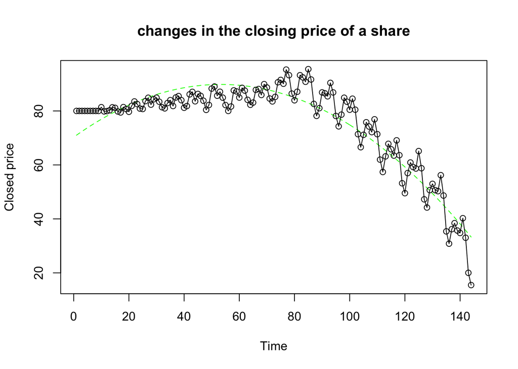

```r
#P value of the quadratic model indicates that the model is significant as the p vale is less than 0.05, however being very close to zero also means that we need to reject the null hypotheses. Hence, we look at the r squared value 0.8807, its suggest that the model is more significant than linear model
plot(ts(fitted(model.ASX1.qa)), ylim = c(min(c(fitted(model.ASX1.qa),
                                                as.vector(ASX1))), max(c(fitted(model.ASX1.qa),as.vector(ASX1)))),
     ylab='Closed price' , main = "changes in the closing price of a share", type="l",lty=2,col="Green")
lines(as.vector(ASX1),type="o")
```

```r
## Residual analysis
#data points above the line, the residual is positive, and for data points below the line, the residual is negative. The closer a data point's residual is to 0, the better the fit.
res.model.ASX1.qa = rstudent(model.ASX1.qa)
# win.graph(width=4.875, height=2.5,pointsize=8) # Use this for Windows computers
#x11() # Use this for Mac computers
par(mfrow=c(2,2))
plot(y = res.model.ASX1.qa, x = as.vector(time(ASX1)),xlab = 'Time in days', ylab='Standardized Residuals',type='l',main = "Standardised residuals from quadratic model.")

hist(res.model.ASX1.qa,xlab='Standardized Residuals', main = "Histogram of standardised residuals.")
qqnorm(y=res.model.ASX1.qa, main = "QQ plot of standardised residuals.")
qqline(y=res.model.ASX1.qa, col = 2, lwd = 1, lty = 2)  #"QQ line of standardised residuals")
shapiro.test(res.model.ASX1.qa)  # shapiro of standardised residuals")
```

```
##
##  Shapiro-Wilk normality test
##
## data:  res.model.ASX1.qa
## W = 0.98771, p-value = 0.2324
```

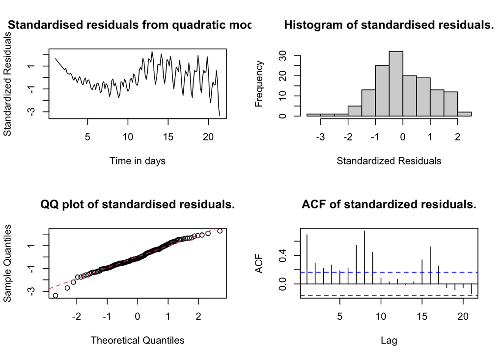

```r
#
#If the Sig. value of the Shapiro-Wilk Test is greater than 0.05, the data is normal. If it is below 0.05, the data significantly deviate from a normal distribution.
acf(res.model.ASX1.qa, main = "ACF of standardized residuals.")
```

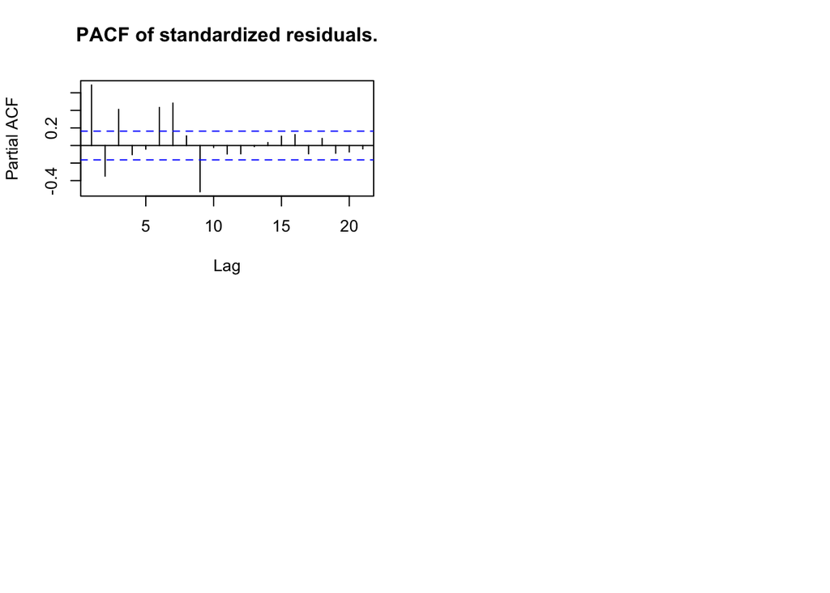

```r
pacf(res.model.ASX1.qa, main = "PACF of standardized residuals.")
par(mfrow=c(1,1))
```

Interpretation of Quadratic model: * P value of the quadratic model indicates that the model is significant as the p vale is less than 0.05, however being very close to zero also means that we need to reject the null hypotheses. Hence, we look at the r squared value 0.8807, its suggest that the model is more significant than linear model * Histogram has improved but still there are some residuals. * QQ plots seems normal except some residuals, while acf and pcf model is improved but still some lags are significant. * Overall results has been improved as compare to linear model. * If the Sig. value of the Shapiro-Wilk Test is greater than 0.05, the data is normal. If it is below 0.05, the data significantly deviate from a normal distribution.